# DivSup: Full-Sample Analyses

## Descriptive Statistics

Means and standard deviations for continuous variables.

```r
mean_sd("age")
```

| mean | sd |
| --- | --- |
| 50.19382 | 10.74221 |

```r
mean_sd("years_experience")
```

| mean | sd |
| --- | --- |
| 18.30401 | 11.15531 |

```r
mean_sd("research_time")
```

| mean | sd |
| --- | --- |
| 69.70005 | 20.70075 |

```r
mean_sd("research_funding")
```

| mean | sd |
| --- | --- |
| 60.17697 | 29.4073 |

Counts and percents for categorical variables, excluding missing values. Because not all participants responded to all questions, the overall N’s will be different for some of these tables. Also note that some variables are recoded for analysis (more on that below, as it comes up).

```r
n_pct("gender")
```

| gender | n | pct |
| --- | --- | --- |
| Man | 1191 | 40.3% |
| TGD | 15 | 0.5% |
| Woman | 1747 | 59.2% |

```r
n_pct("race_ethnicity")
```

| race_ethnicity | n | pct |
| --- | --- | --- |
| AI/AN non-Hispanic | 7 | 0.2% |
| Asian non-Hispanic | 281 | 9.6% |
| Black non-Hispanic | 92 | 3.1% |
| Hispanic | 224 | 7.6% |
| Multiple non-Hispanic | 67 | 2.3% |
| NH/PI non-Hispanic | 1 | 0.0% |
| Other non-Hispanic | 70 | 2.4% |
| White non-Hispanic | 2187 | 74.7% |

```r
n_pct("discipline")
```

| discipline | n | pct |
| --- | --- | --- |
| Behavioral Health | 319 | 8.5% |
| Biology | 1139 | 30.3% |
| Chemistry | 132 | 3.5% |
| Clinical Psychology | 250 | 6.6% |
| Cognitive Psychology | 59 | 1.6% |
| Epidemiology | 305 | 8.1% |
| Neuroscience | 587 | 15.6% |
| Other (please specify) | 706 | 18.8% |
| Pharmacology | 105 | 2.8% |
| Psychiatry | 50 | 1.3% |
| Social Psychology | 29 | 0.8% |
| Virology | 79 | 2.1% |

```r
n_pct("institution_type")
```

| institution_type | n | pct |
| --- | --- | --- |
| Academic Medical Center | 1408 | 47.3% |
| Nonprofit Research/Funding Agency (e.g., AFSP) | 37 | 1.2% |
| Other (please specify) | 200 | 6.7% |
| Private Research Institution (e.g., RAND) | 72 | 2.4% |
| Small College | 41 | 1.4% |
| University/psychology department | 1219 | 40.9% |

```r
n_pct("job_title")
```

| job_title | n | pct |
| --- | --- | --- |
| Assistant Professor | 579 | 19.4% |
| Associate Professor | 834 | 28.0% |
| Full Professor | 1267 | 42.5% |
| Other (please specify) | 221 | 7.4% |
| Project Scientist | 52 | 1.7% |
| Research Psychologist | 25 | 0.8% |

```r
n_pct("mentor_undergrad")
```

| mentor_undergrad | n | pct |
| --- | --- | --- |
| FALSE | 1646 | 44.6% |
| TRUE | 2043 | 55.4% |

```r
n_pct("mentor_postbac")
```

| mentor_postbac | n | pct |
| --- | --- | --- |
| FALSE | 2622 | 71.1% |
| TRUE | 1067 | 28.9% |

```r
n_pct("mentor_masters")
```

| mentor_masters | n | pct |
| --- | --- | --- |
| FALSE | 2318 | 62.8% |
| TRUE | 1371 | 37.2% |

```r
n_pct("mentor_doctoral")
```

| mentor_doctoral | n | pct |
| --- | --- | --- |
| FALSE | 1138 | 30.8% |
| TRUE | 2551 | 69.2% |

```r
n_pct("mentor_postdoc")
```

| mentor_postdoc | n | pct |
| --- | --- | --- |
| FALSE | 1486 | 40.3% |
| TRUE | 2203 | 59.7% |

```r
n_pct("mentor_ecr")
```

| mentor_ecr | n | pct |
| --- | --- | --- |
| FALSE | 2148 | 58.2% |
| TRUE | 1541 | 41.8% |

```r
n_pct("div_sup_applied")
```

| div_sup_applied | n | pct |
| --- | --- | --- |
| FALSE | 2166 | 57.3% |
| TRUE | 1614 | 42.7% |

```r
n_pct("div_sup_granted")
```

| div_sup_granted | n | pct |
| --- | --- | --- |
| FALSE | 249 | 15.4% |
| TRUE | 1365 | 84.6% |

## Application by Researcher Characteristics

These first tables show the *bivariate models* - i.e., models that look at each IV in isolation, without controlling for other IVs. For models predicting application, race/ethnicity was recoded such that the categories AI/AN, NH/PI, multiple, and other were collapsed into “other”.

```r
# Bivariate models
for(x in researcher_characteristics) {

  model <- glm(
    data = clean_data,
    formula = as.formula("div_sup_applied ~ " %+% x),
    family = "binomial"
  )

  model %>%
    summary() %>%
    coef() %>%
    kable() %>%
    kable_styling()

  or <- or_glm(clean_data, model, incr = list(
    age = 10,
    research_time = 10,
    research_funding = 10,
    years_experience = 10
  ))

  or %>%
    kable() %>%
    kable_styling() %>%
    print()

}
```

| predictor | oddsratio | ci_low (2.5) | ci_high (97.5) | increment |
| --- | --- | --- | --- | --- |
| age | 1.526 | 1.413 | 1.649 | 10 |

| predictor | oddsratio | ci_low (2.5) | ci_high (97.5) | increment |
| --- | --- | --- | --- | --- |
| gender_factorMan | 1.412 | 1.215 | 1.641 | Indicator variable |
| gender_factorTGD | 0.645 | 0.178 | 1.894 | Indicator variable |

| predictor | oddsratio | ci_low (2.5) | ci_high (97.5) | increment |
| --- | --- | --- | --- | --- |
| race_ethnicity_recodedAsian non-Hispanic | 0.874 | 0.673 | 1.130 | Indicator variable |
| race_ethnicity_recodedBlack non-Hispanic | 1.450 | 0.952 | 2.203 | Indicator variable |
| race_ethnicity_recodedHispanic | 1.208 | 0.914 | 1.594 | Indicator variable |
| race_ethnicity_recodedOther non-Hispanic | 1.055 | 0.745 | 1.482 | Indicator variable |

| predictor | oddsratio | ci_low (2.5) | ci_high (97.5) | increment |
| --- | --- | --- | --- | --- |
| discipline_factorBehavioral Health | 0.723 | 0.560 | 0.930 | Indicator variable |
| discipline_factorChemistry | 0.693 | 0.476 | 1.000 | Indicator variable |
| discipline_factorClinical Psychology | 0.810 | 0.613 | 1.067 | Indicator variable |
| discipline_factorCognitive Psychology | 0.628 | 0.358 | 1.073 | Indicator variable |
| discipline_factorEpidemiology | 0.833 | 0.645 | 1.075 | Indicator variable |
| discipline_factorNeuroscience | 0.879 | 0.719 | 1.074 | Indicator variable |
| discipline_factorOther (please specify) | 0.752 | 0.621 | 0.909 | Indicator variable |
| discipline_factorPharmacology | 0.789 | 0.523 | 1.180 | Indicator variable |
| discipline_factorPsychiatry | 0.969 | 0.545 | 1.709 | Indicator variable |
| discipline_factorSocial Psychology | 0.695 | 0.315 | 1.464 | Indicator variable |
| discipline_factorVirology | 0.659 | 0.407 | 1.050 | Indicator variable |

| predictor | oddsratio | ci_low (2.5) | ci_high (97.5) | increment |
| --- | --- | --- | --- | --- |
| institution_typeNonprofit Research/Funding Agency (e.g., AFSP) | 0.643 | 0.302 | 1.278 | Indicator variable |
| institution_typeOther (please specify) | 0.992 | 0.730 | 1.340 | Indicator variable |
| institution_typePrivate Research Institution (e.g., RAND) | 0.759 | 0.453 | 1.241 | Indicator variable |
| institution_typeSmall College | 0.490 | 0.226 | 0.973 | Indicator variable |
| institution_typeUniversity/psychology department | 1.007 | 0.861 | 1.178 | Indicator variable |

| predictor | oddsratio | ci_low (2.5) | ci_high (97.5) | increment |
| --- | --- | --- | --- | --- |
| job_titleAssociate Professor | 1.673 | 1.318 | 2.130 | Indicator variable |
| job_titleFull Professor | 3.564 | 2.863 | 4.460 | Indicator variable |
| job_titleOther (please specify) | 1.357 | 0.956 | 1.916 | Indicator variable |
| job_titleProject Scientist | 1.321 | 0.684 | 2.434 | Indicator variable |
| job_titleResearch Psychologist | 1.267 | 0.484 | 2.975 | Indicator variable |

| predictor | oddsratio | ci_low (2.5) | ci_high (97.5) | increment |
| --- | --- | --- | --- | --- |
| research_time | 1.006 | 0.975 | 1.038 | 10 |

| predictor | oddsratio | ci_low (2.5) | ci_high (97.5) | increment |
| --- | --- | --- | --- | --- |
| research_funding | 0.986 | 0.964 | 1.008 | 10 |

| predictor | oddsratio | ci_low (2.5) | ci_high (97.5) | increment |
| --- | --- | --- | --- | --- |
| years_experience | 1.475 | 1.388 | 1.568 | 10 |

| predictor | oddsratio | ci_low (2.5) | ci_high (97.5) | increment |
| --- | --- | --- | --- | --- |
| mentor_undergradTRUE | 0.842 | 0.738 | 0.96 | Indicator variable |

| predictor | oddsratio | ci_low (2.5) | ci_high (97.5) | increment |
| --- | --- | --- | --- | --- |
| mentor_postbacTRUE | 1.226 | 1.063 | 1.415 | Indicator variable |

| predictor | oddsratio | ci_low (2.5) | ci_high (97.5) | increment |
| --- | --- | --- | --- | --- |
| mentor_mastersTRUE | 0.927 | 0.81 | 1.061 | Indicator variable |

| predictor | oddsratio | ci_low (2.5) | ci_high (97.5) | increment |
| --- | --- | --- | --- | --- |
| mentor_doctoralTRUE | 1.472 | 1.276 | 1.7 | Indicator variable |

| predictor | oddsratio | ci_low (2.5) | ci_high (97.5) | increment |
| --- | --- | --- | --- | --- |
| mentor_postdocTRUE | 1.262 | 1.105 | 1.443 | Indicator variable |

| predictor | oddsratio | ci_low (2.5) | ci_high (97.5) | increment |
| --- | --- | --- | --- | --- |
| mentor_ecrTRUE | 1.171 | 1.026 | 1.336 | Indicator variable |

This table includes results for the combined model.

```r
# Combined model
combined_model <- glm(
  data = clean_data,
  formula = as.formula("div_sup_applied ~ " %+% paste0(researcher_characteristics, collapse = " + ")),
  family = "binomial"
)

p_values <- combined_model %>%
  summary() %>%
  coef() %>%
  as_tibble(rownames = "predictor") %>%
  select(predictor, p = `Pr(>|z|)`)

or <- or_glm(clean_data, combined_model, incr = list(
  age = 10,
  research_time = 10,
  research_funding = 10,
  years_experience = 10
))

or %>%
  left_join(p_values, by = "predictor", relationship = "one-to-one") %>%
  kable() %>%
  kable_styling()
```

| predictor | oddsratio | ci_low (2.5) | ci_high (97.5) | increment | p |
| --- | --- | --- | --- | --- | --- |
| age | 0.994 | 0.849 | 1.162 | 10 | 0.9390758 |
| gender_factorMan | 1.162 | 0.961 | 1.403 | Indicator variable | 0.1201009 |
| gender_factorTGD | 0.642 | 0.167 | 2.069 | Indicator variable | 0.4788672 |
| race_ethnicity_recodedAsian non-Hispanic | 0.965 | 0.703 | 1.318 | Indicator variable | 0.8232286 |
| race_ethnicity_recodedBlack non-Hispanic | 2.104 | 1.284 | 3.444 | Indicator variable | 0.0030339 |
| race_ethnicity_recodedHispanic | 1.737 | 1.233 | 2.447 | Indicator variable | 0.0015780 |
| race_ethnicity_recodedOther non-Hispanic | 1.421 | 0.943 | 2.136 | Indicator variable | 0.0909528 |
| discipline_factorBehavioral Health | 0.525 | 0.364 | 0.751 | Indicator variable | 0.0004772 |
| discipline_factorChemistry | 0.805 | 0.465 | 1.380 | Indicator variable | 0.4323809 |
| discipline_factorClinical Psychology | 0.804 | 0.551 | 1.167 | Indicator variable | 0.2529995 |
| discipline_factorCognitive Psychology | 0.625 | 0.301 | 1.249 | Indicator variable | 0.1925974 |
| discipline_factorEpidemiology | 0.672 | 0.464 | 0.968 | Indicator variable | 0.0337921 |
| discipline_factorNeuroscience | 0.861 | 0.651 | 1.138 | Indicator variable | 0.2943293 |
| discipline_factorOther (please specify) | 0.705 | 0.539 | 0.921 | Indicator variable | 0.0104642 |
| discipline_factorPharmacology | 0.557 | 0.299 | 1.012 | Indicator variable | 0.0583643 |
| discipline_factorPsychiatry | 0.984 | 0.436 | 2.193 | Indicator variable | 0.9684563 |
| discipline_factorSocial Psychology | 0.845 | 0.312 | 2.196 | Indicator variable | 0.7307540 |
| discipline_factorVirology | 0.561 | 0.275 | 1.118 | Indicator variable | 0.1050111 |
| institution_typeNonprofit Research/Funding Agency (e.g., AFSP) | 1.305 | 0.549 | 3.027 | Indicator variable | 0.5369820 |
| institution_typeOther (please specify) | 1.160 | 0.787 | 1.705 | Indicator variable | 0.4522777 |
| institution_typePrivate Research Institution (e.g., RAND) | 0.889 | 0.440 | 1.749 | Indicator variable | 0.7358584 |
| institution_typeSmall College | 0.650 | 0.242 | 1.565 | Indicator variable | 0.3583867 |
| institution_typeUniversity/psychology department | 1.216 | 0.983 | 1.506 | Indicator variable | 0.0722288 |
| job_titleAssociate Professor | 1.377 | 1.046 | 1.819 | Indicator variable | 0.0234076 |
| job_titleFull Professor | 2.280 | 1.648 | 3.162 | Indicator variable | 0.0000007 |
| job_titleOther (please specify) | 1.105 | 0.717 | 1.690 | Indicator variable | 0.6476168 |
| job_titleProject Scientist | 0.684 | 0.300 | 1.470 | Indicator variable | 0.3452394 |
| job_titleResearch Psychologist | 0.964 | 0.256 | 2.985 | Indicator variable | 0.9515385 |
| research_time | 1.054 | 0.989 | 1.124 | 10 | 0.1059020 |
| research_funding | 0.993 | 0.949 | 1.040 | 10 | 0.7757239 |
| years_experience | 1.404 | 1.201 | 1.645 | 10 | 0.0000230 |
| mentor_undergradTRUE | 0.661 | 0.534 | 0.818 | Indicator variable | 0.0001450 |
| mentor_postbacTRUE | 1.408 | 1.136 | 1.744 | Indicator variable | 0.0017555 |
| mentor_mastersTRUE | 0.965 | 0.788 | 1.180 | Indicator variable | 0.7272068 |
| mentor_doctoralTRUE | 1.371 | 1.098 | 1.713 | Indicator variable | 0.0054315 |
| mentor_postdocTRUE | 1.013 | 0.827 | 1.240 | Indicator variable | 0.9024462 |
| mentor_ecrTRUE | 1.031 | 0.845 | 1.257 | Indicator variable | 0.7651501 |

## Success by Researcher Characteristics

Same as above - this section is the bivariate models. Because the sample size for these analyses is smaller (limited to only respondents who applied for a DS), some new categorical variables had to be recoded (to prevent categories whose n’s were too small to model). In addition to recoding race (as above), gender was recoded to make TGD (n = 4) NA (i.e., drop these respondents), discipline was recoded to make social psychology (n = 11) NA, and institution was recoded to make small college (n = 10) NA.

```r
data_success <- clean_data %>%
  drop_na(div_sup_granted) %>%
  mutate(
    gender_factor = na_if(gender_factor, "TGD"),
    discipline_factor = na_if(discipline_factor, "Social Psychology"),
    institution_type = na_if(institution_type, "Small College")
  )

# Bivariate models
for(x in researcher_characteristics) {

  model <- glm(
    data = data_success,
    formula = as.formula("div_sup_granted ~ " %+% x),
    family = "binomial"
  )

  model %>%
    summary() %>%
    coef() %>%
    kable() %>%
    kable_styling()

  or <- or_glm(data_success, model, incr = list(
    age = 10,
    research_time = 10,
    research_funding = 10,
    years_experience = 10
  ))

  or %>%
    kable() %>%
    kable_styling() %>%
    print()

}
```

| predictor | oddsratio | ci_low (2.5) | ci_high (97.5) | increment |
| --- | --- | --- | --- | --- |
| age | 1.097 | 0.934 | 1.292 | 10 |

| predictor | oddsratio | ci_low (2.5) | ci_high (97.5) | increment |
| --- | --- | --- | --- | --- |
| gender_factorMan | 1.059 | 0.764 | 1.474 | Indicator variable |

| predictor | oddsratio | ci_low (2.5) | ci_high (97.5) | increment |
| --- | --- | --- | --- | --- |
| race_ethnicity_recodedAsian non-Hispanic | 0.627 | 0.380 | 1.075 | Indicator variable |
| race_ethnicity_recodedBlack non-Hispanic | 1.056 | 0.469 | 2.826 | Indicator variable |
| race_ethnicity_recodedHispanic | 1.077 | 0.602 | 2.078 | Indicator variable |
| race_ethnicity_recodedOther non-Hispanic | 1.214 | 0.574 | 2.989 | Indicator variable |

| predictor | oddsratio | ci_low (2.5) | ci_high (97.5) | increment |
| --- | --- | --- | --- | --- |
| discipline_factorBehavioral Health | 0.579 | 0.360 | 0.952 | Indicator variable |
| discipline_factorChemistry | 1.037 | 0.477 | 2.597 | Indicator variable |
| discipline_factorClinical Psychology | 0.929 | 0.529 | 1.717 | Indicator variable |
| discipline_factorCognitive Psychology | 3.377 | 0.688 | 61.042 | Indicator variable |
| discipline_factorEpidemiology | 1.387 | 0.779 | 2.637 | Indicator variable |
| discipline_factorNeuroscience | 0.860 | 0.574 | 1.304 | Indicator variable |
| discipline_factorOther (please specify) | 0.863 | 0.582 | 1.291 | Indicator variable |
| discipline_factorPharmacology | 0.868 | 0.395 | 2.192 | Indicator variable |
| discipline_factorPsychiatry | 0.802 | 0.292 | 2.823 | Indicator variable |
| discipline_factorVirology | 0.811 | 0.324 | 2.464 | Indicator variable |

| predictor | oddsratio | ci_low (2.5) | ci_high (97.5) | increment |
| --- | --- | --- | --- | --- |
| institution_typeNonprofit Research/Funding Agency (e.g., AFSP) | 1.598 | 0.300 | 29.524 | Indicator variable |
| institution_typeOther (please specify) | 0.988 | 0.518 | 2.048 | Indicator variable |
| institution_typePrivate Research Institution (e.g., RAND) | 0.799 | 0.293 | 2.801 | Indicator variable |
| institution_typeUniversity/psychology department | 0.836 | 0.594 | 1.176 | Indicator variable |

| predictor | oddsratio | ci_low (2.5) | ci_high (97.5) | increment |
| --- | --- | --- | --- | --- |
| job_titleAssociate Professor | 0.941 | 0.528 | 1.632 | Indicator variable |
| job_titleFull Professor | 1.191 | 0.696 | 1.963 | Indicator variable |
| job_titleOther (please specify) | 1.301 | 0.561 | 3.291 | Indicator variable |
| job_titleProject Scientist | 0.365 | 0.117 | 1.269 | Indicator variable |
| job_titleResearch Psychologist | 0.243 | 0.050 | 1.309 | Indicator variable |

| predictor | oddsratio | ci_low (2.5) | ci_high (97.5) | increment |
| --- | --- | --- | --- | --- |
| research_time | 1.008 | 0.941 | 1.078 | 10 |

| predictor | oddsratio | ci_low (2.5) | ci_high (97.5) | increment |
| --- | --- | --- | --- | --- |
| research_funding | 1.033 | 0.985 | 1.084 | 10 |

| predictor | oddsratio | ci_low (2.5) | ci_high (97.5) | increment |
| --- | --- | --- | --- | --- |
| years_experience | 1.224 | 1.082 | 1.388 | 10 |

| predictor | oddsratio | ci_low (2.5) | ci_high (97.5) | increment |
| --- | --- | --- | --- | --- |
| mentor_undergradTRUE | 0.671 | 0.507 | 0.885 | Indicator variable |

| predictor | oddsratio | ci_low (2.5) | ci_high (97.5) | increment |
| --- | --- | --- | --- | --- |
| mentor_postbacTRUE | 1.167 | 0.868 | 1.583 | Indicator variable |

| predictor | oddsratio | ci_low (2.5) | ci_high (97.5) | increment |
| --- | --- | --- | --- | --- |
| mentor_mastersTRUE | 0.745 | 0.565 | 0.985 | Indicator variable |

| predictor | oddsratio | ci_low (2.5) | ci_high (97.5) | increment |
| --- | --- | --- | --- | --- |
| mentor_doctoralTRUE | 1.15 | 0.846 | 1.551 | Indicator variable |

| predictor | oddsratio | ci_low (2.5) | ci_high (97.5) | increment |
| --- | --- | --- | --- | --- |
| mentor_postdocTRUE | 1.066 | 0.803 | 1.408 | Indicator variable |

| predictor | oddsratio | ci_low (2.5) | ci_high (97.5) | increment |
| --- | --- | --- | --- | --- |
| mentor_ecrTRUE | 0.715 | 0.544 | 0.939 | Indicator variable |

And the combined model:

```r
# Combined model
combined_model <- glm(
  data = data_success,
  formula = as.formula("div_sup_granted ~ " %+% paste0(researcher_characteristics, collapse = " + ")),
  family = "binomial"
)

p_values <- combined_model %>%
  summary() %>%
  coef() %>%
  as_tibble(rownames = "predictor") %>%
  select(predictor, p = `Pr(>|z|)`)

or <- or_glm(data_success, combined_model, incr = list(
  age = 10,
  research_time = 10,
  research_funding = 10,
  years_experience = 10
))

or %>%
  left_join(p_values, by = "predictor", relationship = "one-to-one") %>%
  kable() %>%
  kable_styling()
```

| predictor | oddsratio | ci_low (2.5) | ci_high (97.5) | increment | p |
| --- | --- | --- | --- | --- | --- |
| age | 0.992 | 0.703 | 1.408 | 10 | 0.9639835 |
| gender_factorMan | 1.198 | 0.803 | 1.795 | Indicator variable | 0.3784449 |
| race_ethnicity_recodedAsian non-Hispanic | 0.762 | 0.408 | 1.505 | Indicator variable | 0.4118518 |
| race_ethnicity_recodedBlack non-Hispanic | 1.065 | 0.411 | 3.327 | Indicator variable | 0.9040749 |
| race_ethnicity_recodedHispanic | 1.628 | 0.797 | 3.696 | Indicator variable | 0.2086071 |
| race_ethnicity_recodedOther non-Hispanic | 1.427 | 0.603 | 3.978 | Indicator variable | 0.4533889 |
| discipline_factorBehavioral Health | 0.898 | 0.415 | 2.060 | Indicator variable | 0.7908639 |
| discipline_factorChemistry | 0.899 | 0.320 | 2.973 | Indicator variable | 0.8491451 |
| discipline_factorClinical Psychology | 1.237 | 0.535 | 3.183 | Indicator variable | 0.6363724 |
| discipline_factorCognitive Psychology | 2.615 | 0.442 | 51.312 | Indicator variable | 0.3844623 |
| discipline_factorEpidemiology | 1.066 | 0.479 | 2.540 | Indicator variable | 0.8789671 |
| discipline_factorNeuroscience | 0.574 | 0.329 | 1.006 | Indicator variable | 0.0502302 |
| discipline_factorOther (please specify) | 0.955 | 0.535 | 1.725 | Indicator variable | 0.8771200 |
| discipline_factorPharmacology | 0.555 | 0.181 | 2.101 | Indicator variable | 0.3355116 |
| discipline_factorPsychiatry | 0.872 | 0.211 | 5.942 | Indicator variable | 0.8654660 |
| discipline_factorVirology | 0.218 | 0.070 | 0.760 | Indicator variable | 0.0108488 |
| institution_typeNonprofit Research/Funding Agency (e.g., AFSP) | 2.197 | 0.343 | 45.443 | Indicator variable | 0.4919856 |
| institution_typeOther (please specify) | 0.820 | 0.381 | 1.896 | Indicator variable | 0.6262062 |
| institution_typePrivate Research Institution (e.g., RAND) | 0.667 | 0.174 | 3.552 | Indicator variable | 0.5892479 |
| institution_typeUniversity/psychology department | 0.857 | 0.544 | 1.352 | Indicator variable | 0.5059192 |
| job_titleAssociate Professor | 0.880 | 0.446 | 1.698 | Indicator variable | 0.7077814 |
| job_titleFull Professor | 0.701 | 0.328 | 1.461 | Indicator variable | 0.3497846 |
| job_titleOther (please specify) | 1.035 | 0.363 | 3.310 | Indicator variable | 0.9506594 |
| job_titleProject Scientist | 0.148 | 0.029 | 0.811 | Indicator variable | 0.0233249 |
| job_titleResearch Psychologist | 0.194 | 0.018 | 2.204 | Indicator variable | 0.1624283 |
| research_time | 0.946 | 0.824 | 1.085 | 10 | 0.4303981 |
| research_funding | 1.063 | 0.961 | 1.174 | 10 | 0.2333221 |
| years_experience | 1.342 | 0.963 | 1.864 | 10 | 0.0805413 |
| mentor_undergradTRUE | 0.543 | 0.337 | 0.868 | Indicator variable | 0.0113807 |
| mentor_postbacTRUE | 1.394 | 0.894 | 2.202 | Indicator variable | 0.1483506 |
| mentor_mastersTRUE | 0.712 | 0.466 | 1.088 | Indicator variable | 0.1160733 |
| mentor_doctoralTRUE | 1.792 | 1.086 | 2.936 | Indicator variable | 0.0211339 |
| mentor_postdocTRUE | 1.195 | 0.756 | 1.880 | Indicator variable | 0.4432577 |
| mentor_ecrTRUE | 0.583 | 0.379 | 0.893 | Indicator variable | 0.0135004 |

## Barriers

```r
barrier_summary_data <- clean_data %>%
  count(top_barrier) %>%
  drop_na() %>%
  mutate(
    top_barrier = fct_reorder(top_barrier, n),
    prop = n / sum(n),
    lower = prop_ci(n, sum(n), "lower"),
    upper = prop_ci(n, sum(n), "upper")
  )

barrier_summary_data %>%
  arrange(desc(n)) %>%
  kable() %>%
  kable_styling()
```

| top_barrier | n | prop | lower | upper |
| --- | --- | --- | --- | --- |
| No Qualifying Mentees | 655 | 0.3561718 | 0.3343385 | 0.3786122 |
| Unclear Re: Eligibility | 330 | 0.1794454 | 0.1623203 | 0.1979275 |
| Not Familiar | 285 | 0.1549755 | 0.1388973 | 0.1725158 |
| Other | 219 | 0.1190865 | 0.1048147 | 0.1349754 |
| Unclear Re: Process | 198 | 0.1076672 | 0.0940541 | 0.1229473 |
| Not Enough Time/Energy | 96 | 0.0522023 | 0.0426908 | 0.0636303 |
| Not Worth the Time/Effort | 36 | 0.0195759 | 0.0139446 | 0.0272949 |
| Didn’t Want To | 14 | 0.0076128 | 0.0043374 | 0.0130769 |
| No Incentives | 5 | 0.0027189 | 0.0010014 | 0.0067266 |
| Others Don’t | 1 | 0.0005438 | 0.0000284 | 0.0035241 |

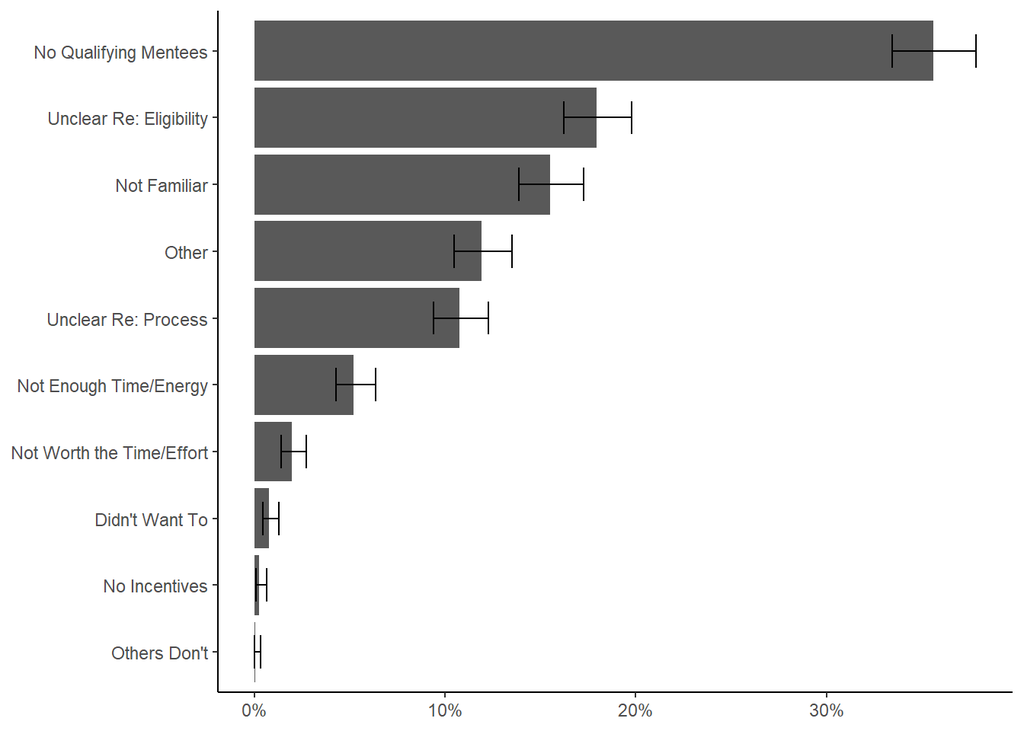

```r
barrier_summary_data %>%
  ggplot(aes(top_barrier, prop)) +
  geom_col() +
  geom_errorbar(aes(ymin = lower, ymax = upper), width = .5) +
  scale_x_discrete(name = NULL) +
  scale_y_continuous(name = NULL, labels = percent) +
  coord_flip() +
  theme_classic()
```